# beta-lot-experiments

Dilsher Singh Dhillon

04 February,2022

## Introduction

```
pate-rnd xmap-collector --include_file_str 20220119_WC_P1vP6 \
  --include_file_str  20220120_ShakeSpd_1000rpm_Panel1_Plate1 \
  --include_file_str  20220120_ShakeSpd_1200rpm_Panel1_Plate2 \
  --include_file_str  20220120_ShakeSpd_1500rpm_Panel1_Plate3 \
  --include_file_str  20220120_ShakeSpd_1000rpm_Panel2_Plate1 \
  --include_file_str  20220120_ShakeSpd_1200rpm_Panel2_Plate2 \
  --include_file_str  20220120_ShakeSpd_1500rpm_Panel2_Plate3 \
  --include_file_str  20220120_ShakeSpd_1200rpm_Panel2_Plate2 \
  --include_file_str  20220120_ShakeSpd_1500rpm_Panel2_Plate2 \
  --include_file_str  Beta \
  --include_file_str  Interf \
  --include_file_str  PltStd \
  --include_file_str  Endogenous \
  --include_file_str  Exogenous \
  --include_file_str  Platinum \
  --include_file_str  Reproducibility \
  --include_file_str  Donor_Screening \
  --include_file_str  PlatinumStd \
  --include_file_str  HamiltonEquiv\
  --include_file_str  ShakingCompare \
  --include_sample_str Standard --include_sample_str Buffer --include_sample_str Background --include_sample_str QC --include_sample_str RC  --ignore_case_sample \
  --out_file_name betalot_experiments-2022-01-25.csv
```

```
gsutil cp gs://inhouse-xmap-data/user_data_frames/betalot_experiments-2022-01-25.csv ~/'google drive'/'my drive'/projects/beta-av-testing/data/raw/beta-lot-stds-controls-2022-01-25.csv
```

### Read in data

#### SAPE (Controls vs 4hr)

According to the (benchling)[https://freenome.benchling.com/freenome/f/lib_rLUfj3iF-06-guardbanding-for-automation/etr_sY3wzurA-bwtm-beta-lot-sa-pe-room-temperature-stability-0-4-hour/edit], the plate 2 or `P2` in the `file_name` the SAPE is prepared 4 hours earlier.

We only need to focus on the top 7 proteins of interest.

```
##  [1] "...1"
##  [2] "xponent_id"
##  [3] "sample_type"
##  [4] "well_id"
##  [5] "well_row"
##  [6] "well_column"
##  [7] "assay"
##  [8] "dilution_factor"
##  [9] "conc_units"
## [10] "standard_expected_concentration"
## [11] "bead_count"
## [12] "median_mfi"
## [13] "avg_median_mfi"
## [14] "pct_cv_median_mfi"
## [15] "net_mfi"
```

[output cut: 27 more lines]

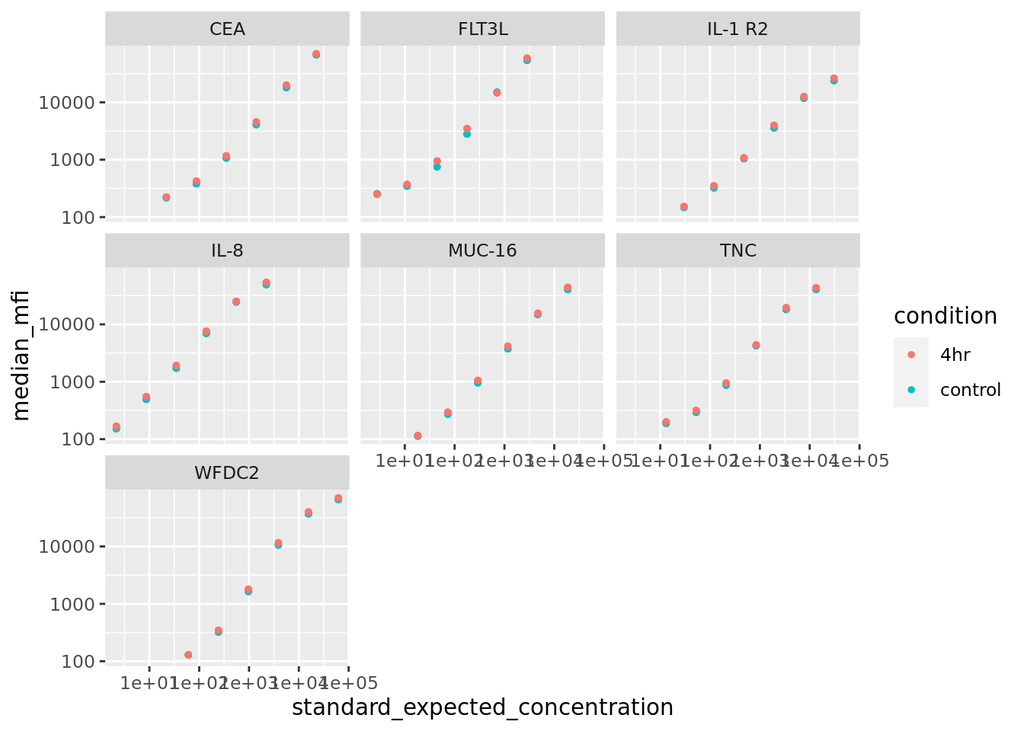

Is this within our expected range? We can import the tolerance intervals we generate for beta lot to assess this

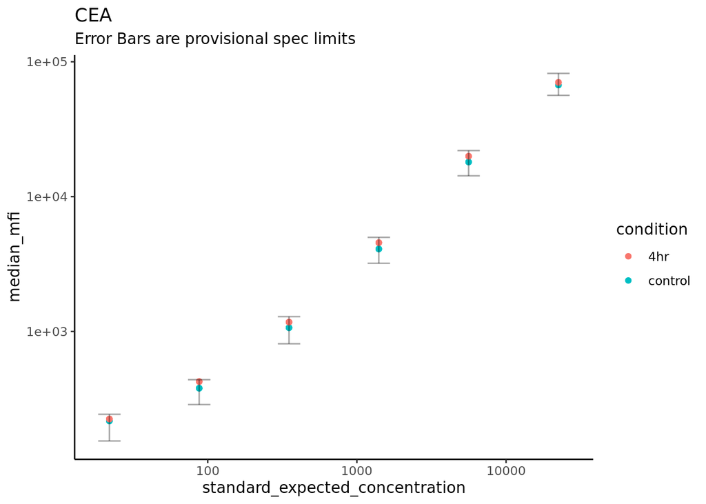

[figure not shown]

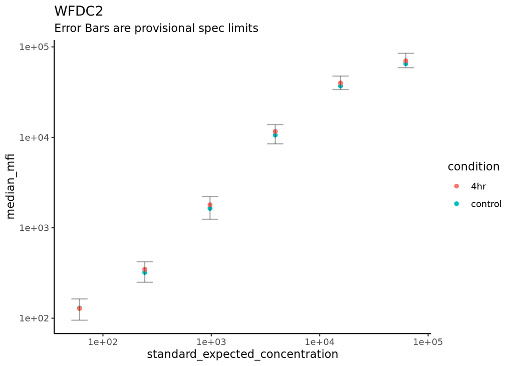

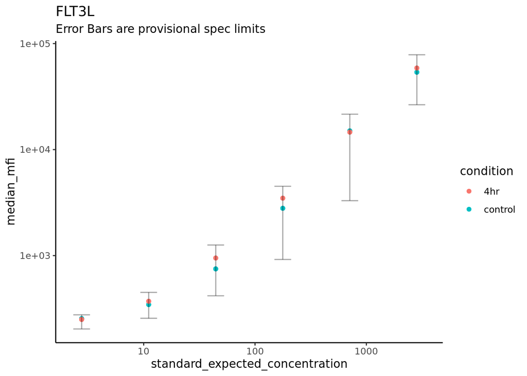

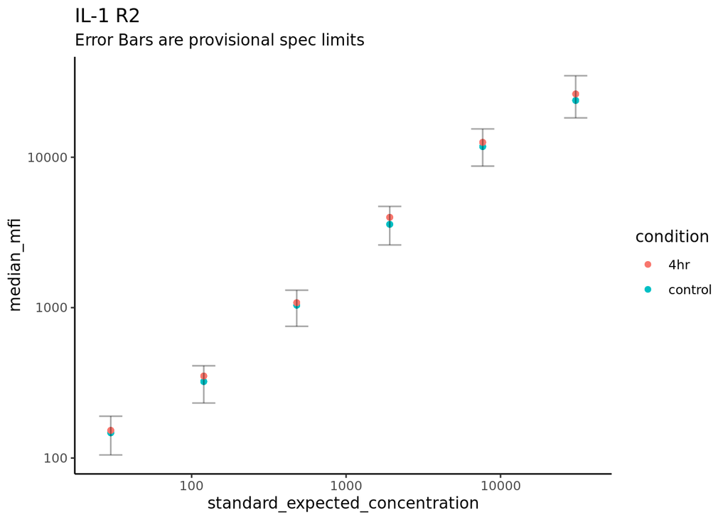

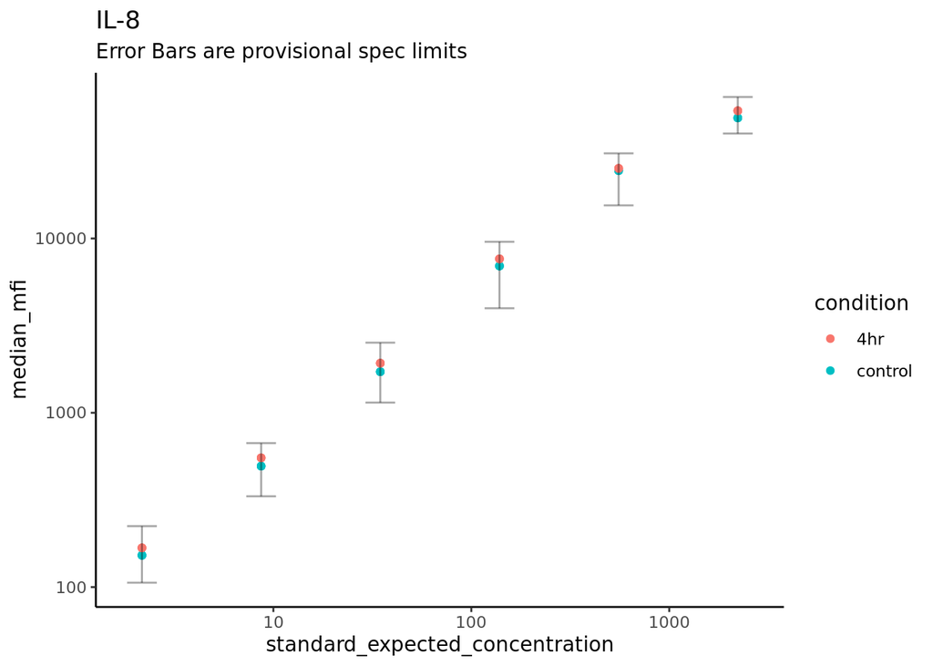

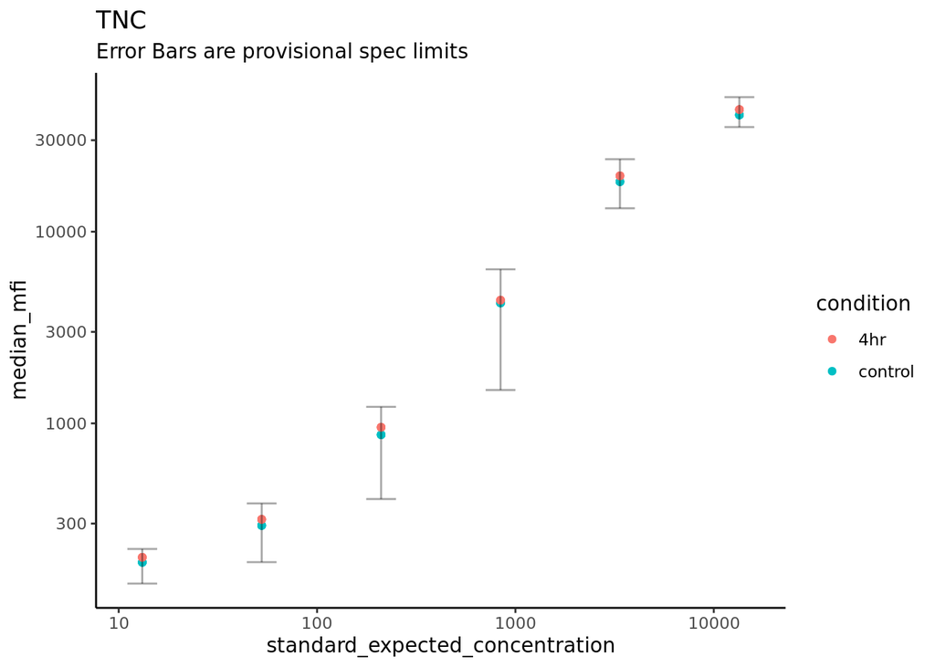

Compare run controls?

These experiments don’t have run controls on them?

```
## # A tibble: 3 x 2
##   sample_type     n
##   <chr>       <int>
## 1 background    112
## 2 sample       4928
## 3 standard      336
```

**Extract all standard 5 MFIs for CEA using the tolerance data**

```
## # A tibble: 2 x 2
##   greater     n
##     <dbl> <int>
## 1       0    35
## 2       1     5
```

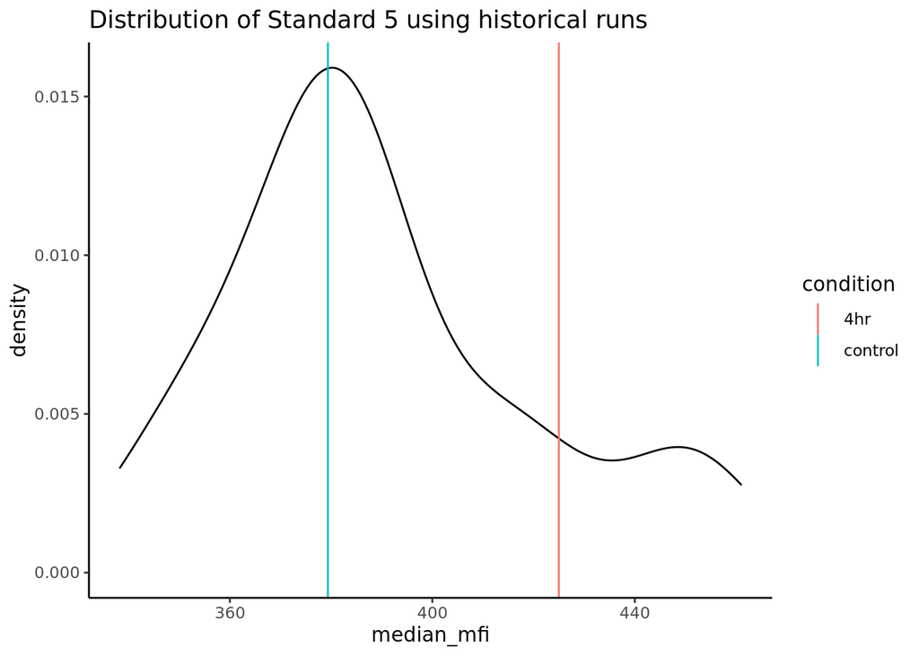

**Recovery**

Does this translate to recovery?

```
## # A tibble: 3 x 2
##   greater     n
##     <dbl> <int>
## 1       0    33
## 2       1     7
## 3      NA     1
```

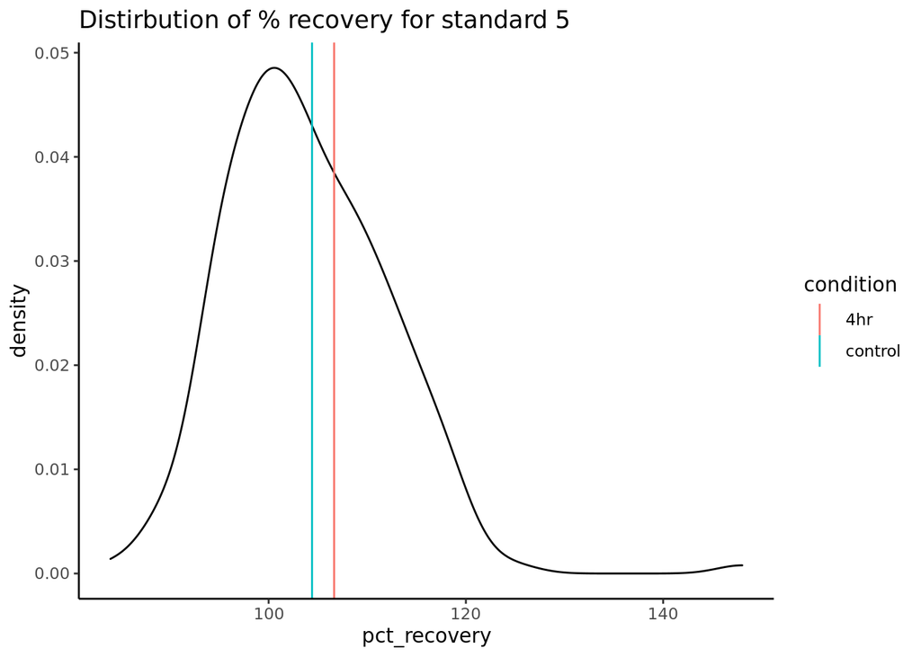

**recovery plots**

#### Workcell experiments

```
## get data from GCS
pate-rnd xmap-collector --include_file_str 20220119_WC_P1vP6 \
  --include_file_str  20220119_WC_P1vP6 \
  --include_sample_str Standard --include_sample_str Buffer --include_sample_str Background --include_sample_str QC --ignore_case_sample \
  --out_file_name workcell-experiments-january-01-26.csv
```

```
gsutil cp gs://inhouse-xmap-data/user_data_frames/workcell-experiments-january-01-26.csv ~/'google drive'/'my drive'/projects/beta-av-testing/data/raw/workcell-experiments-january-01-26.csv
```

In this case, the SAPE time between plate 1 and plate 6 was 30 minutes. But the SAPE time for plate 1 was also 2 hours (instead of 0 as with the controlled experiment above)

Let’s just compare the same assay CEA and the standard 5 and standard 6

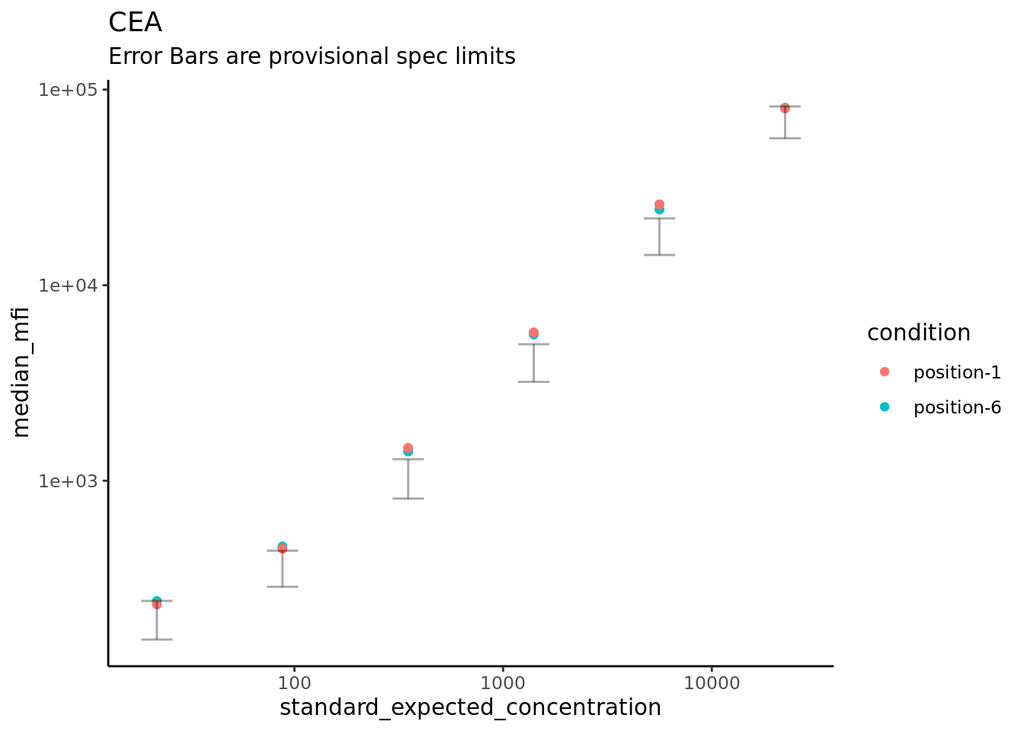

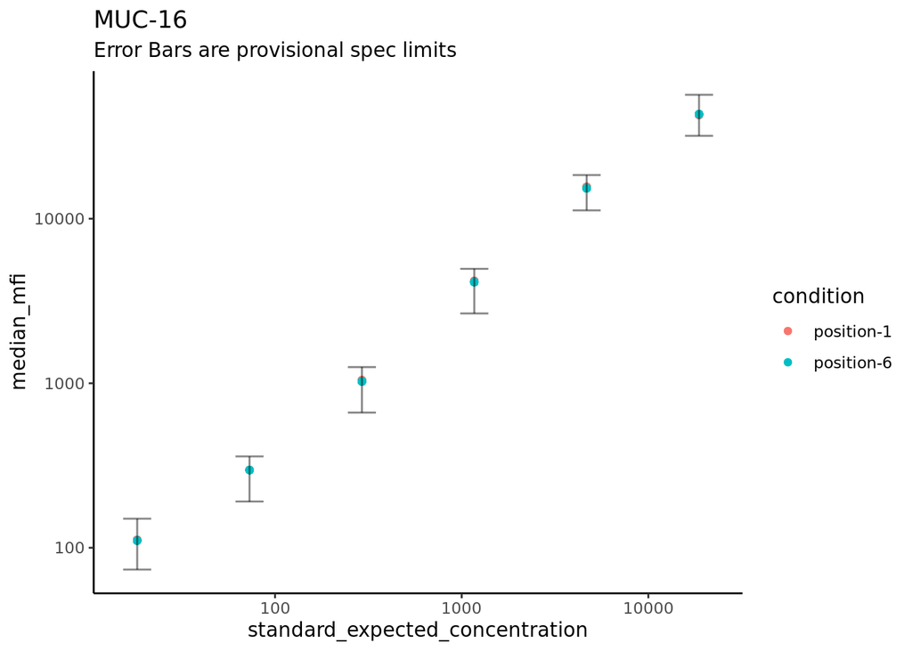

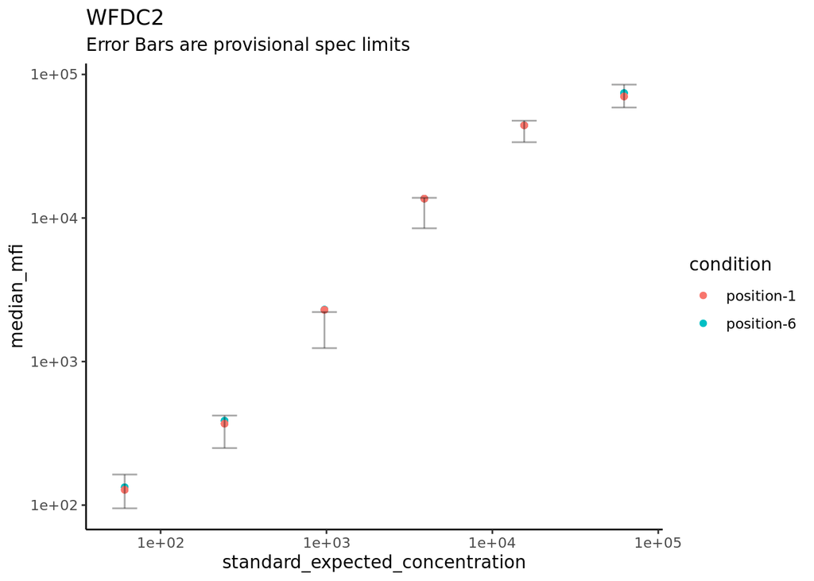

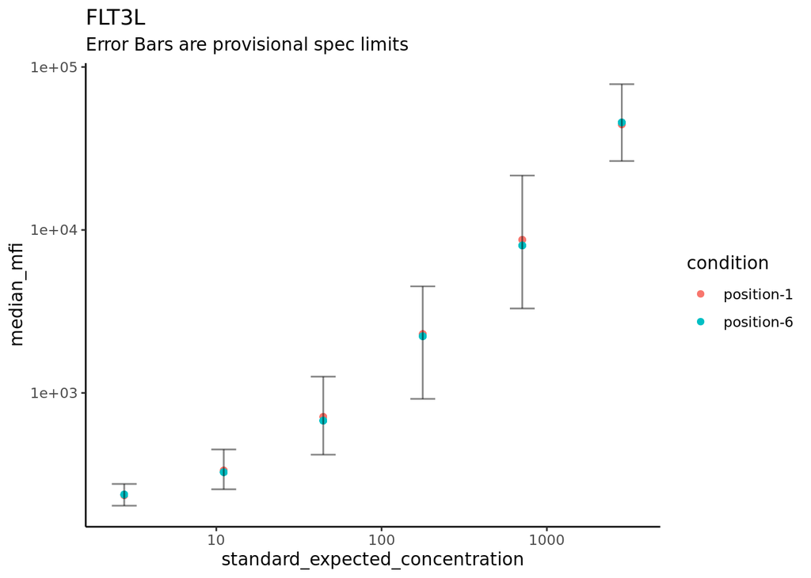

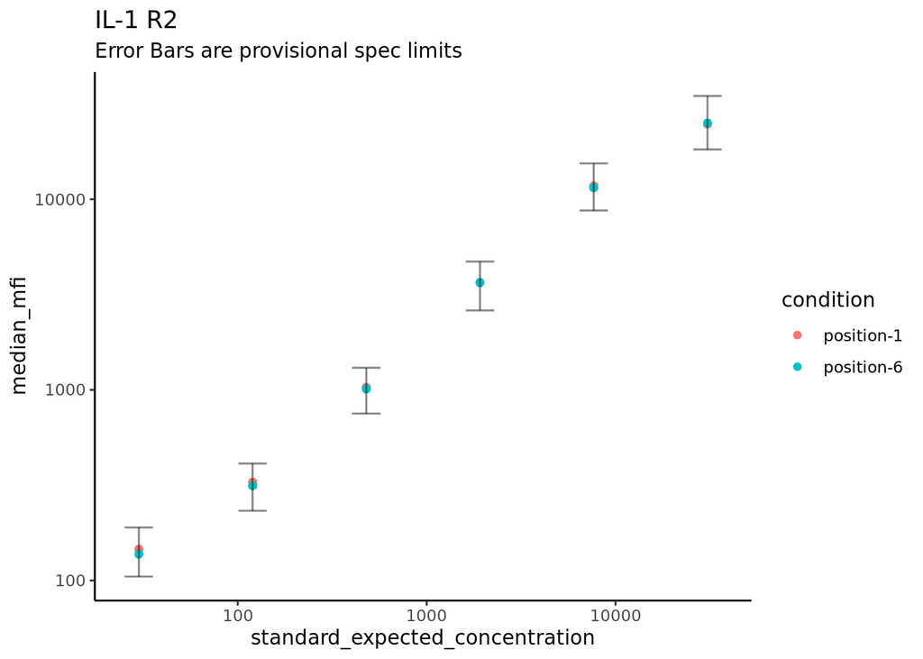

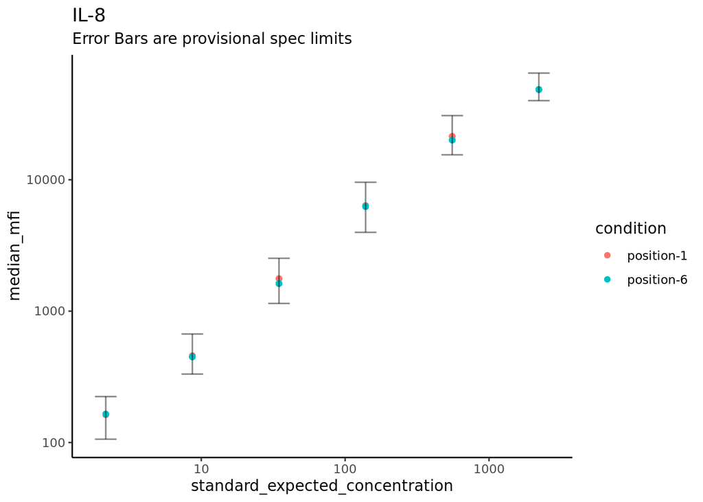

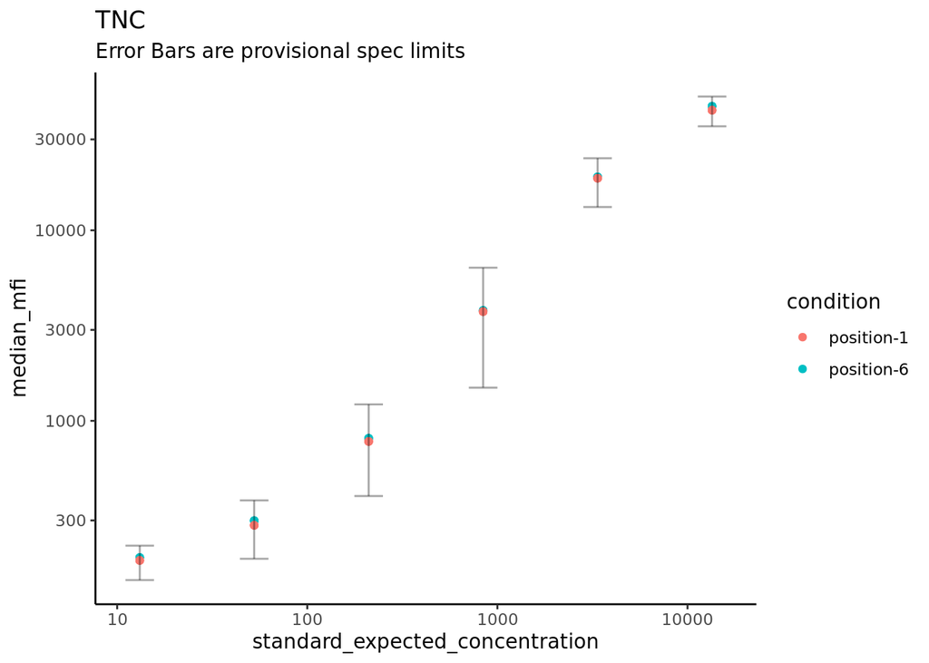

What about % recovery - is that out of spec as well?

```
## # A tibble: 2 x 2
##   condition      n
##   <chr>      <int>
## 1 position-1    24
## 2 position-6    48
```

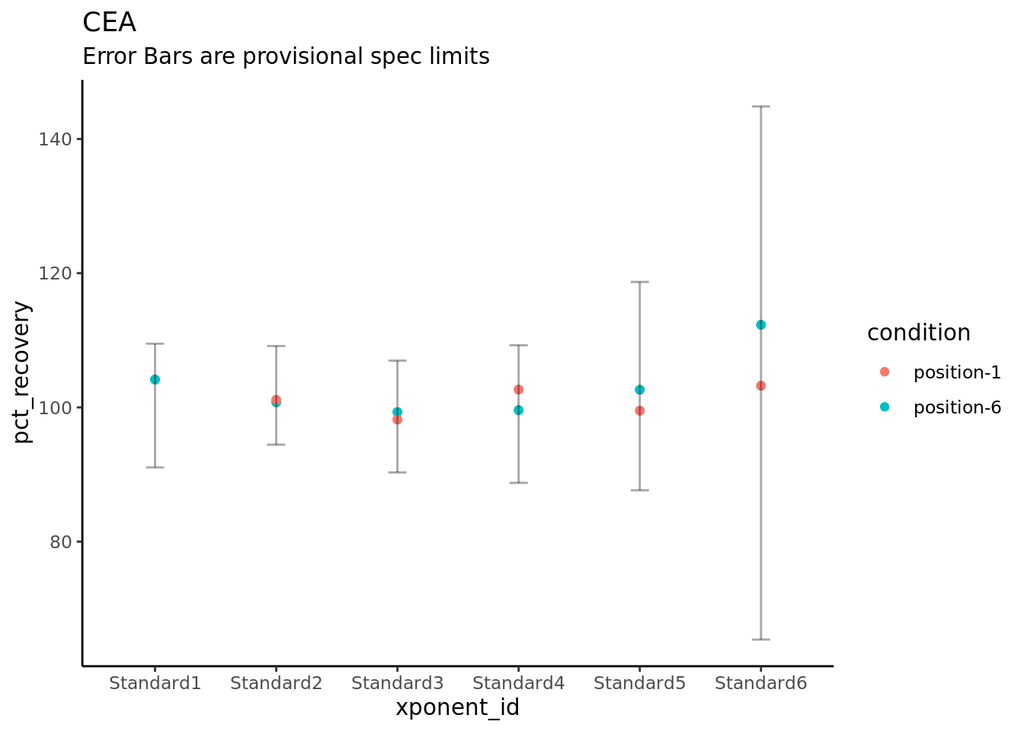

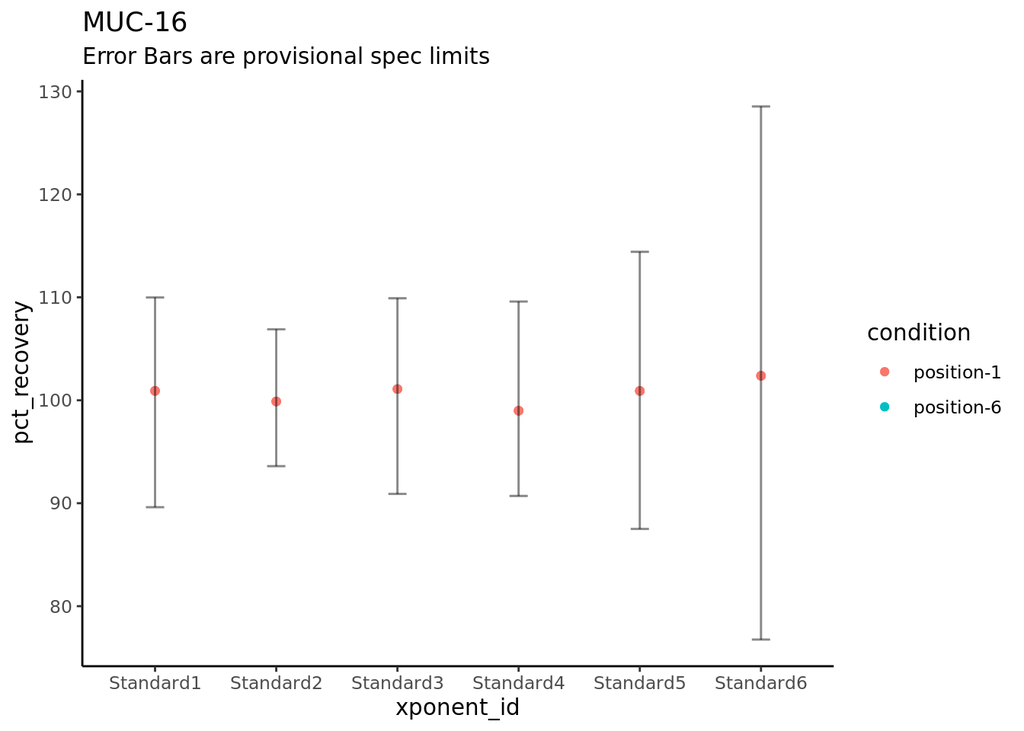

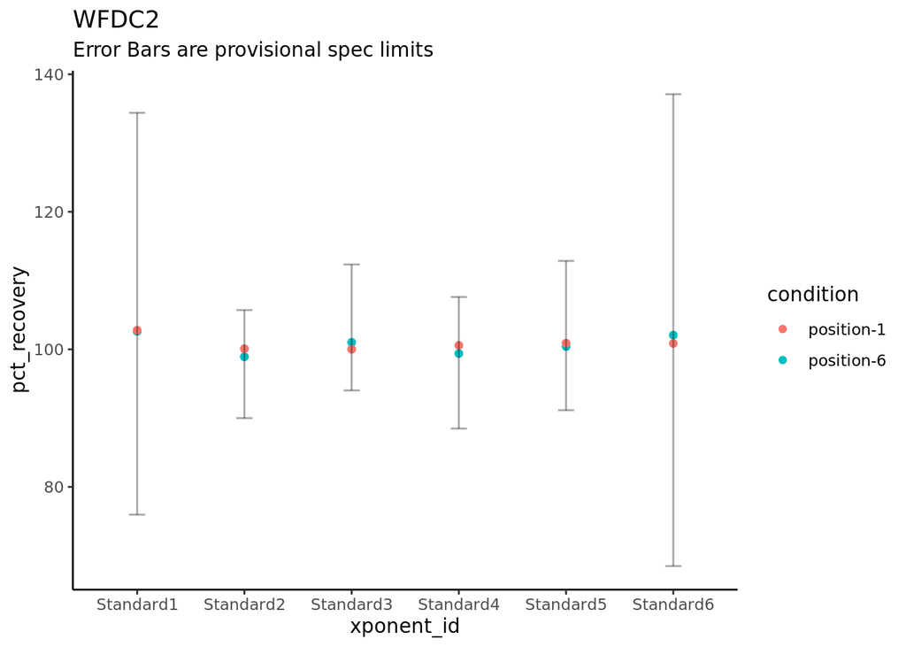

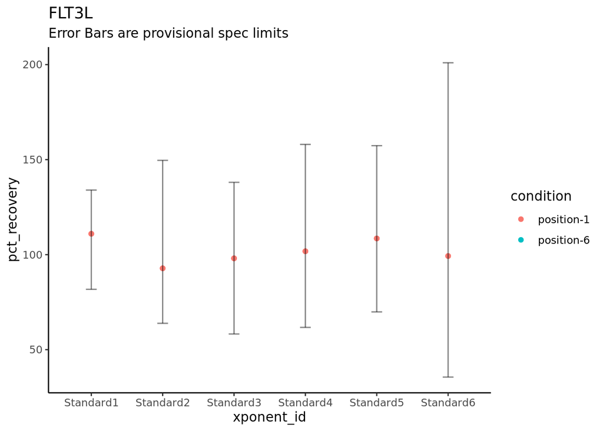

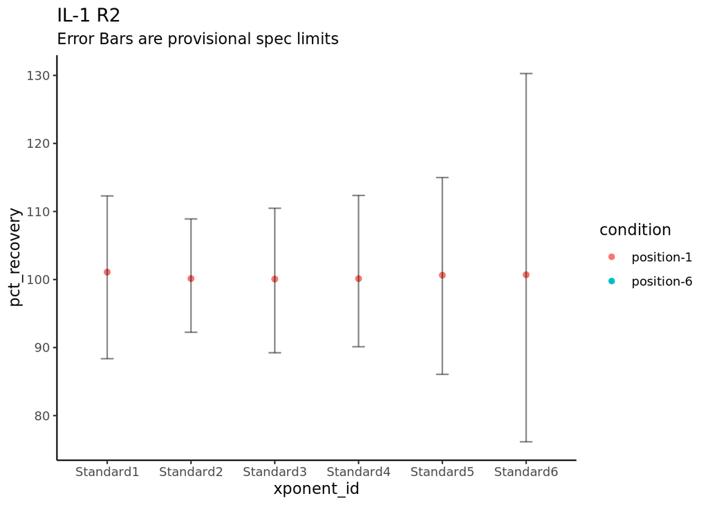

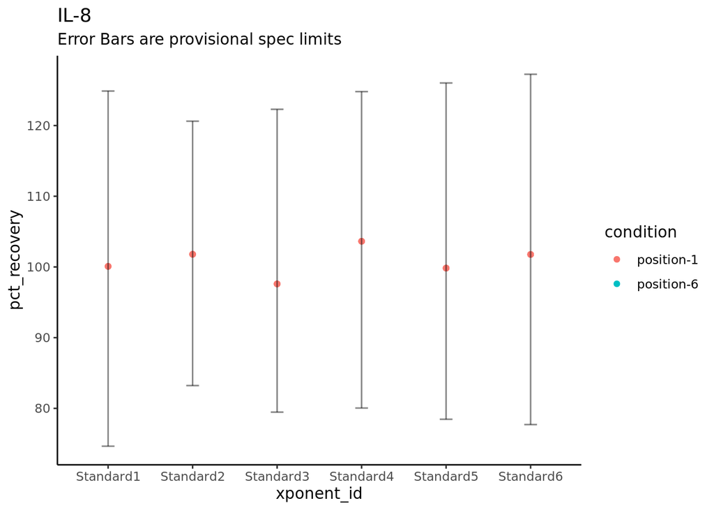

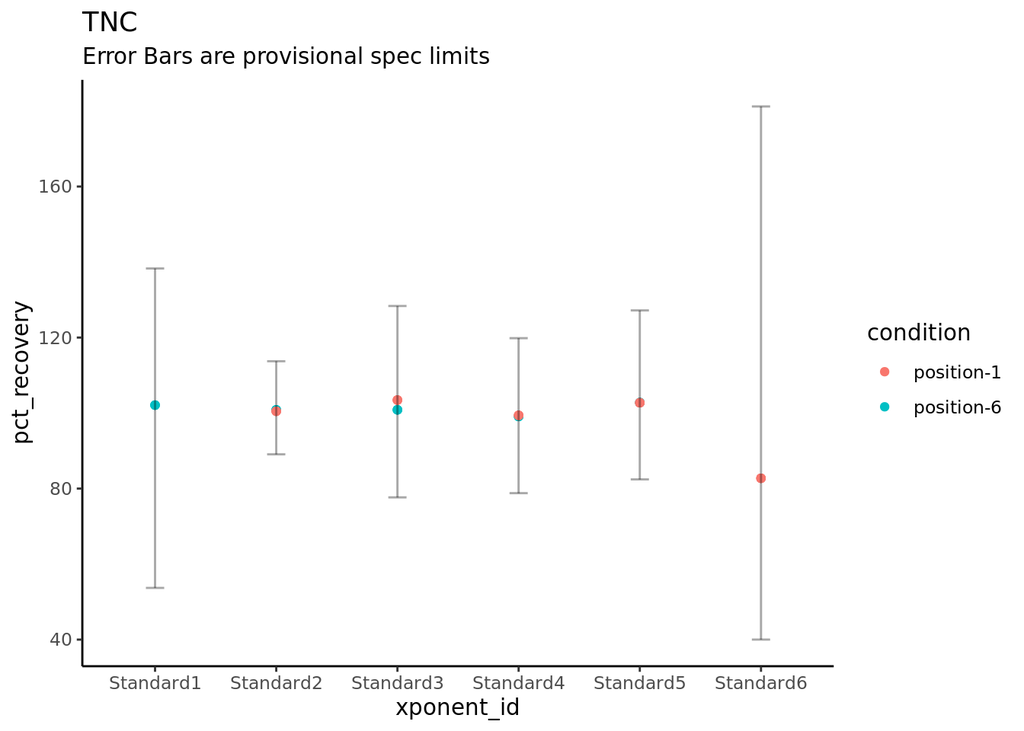

why does MUC-16 have more position 6?

```
## # A tibble: 48 x 41
##     ...1 xponent_id sample_type well_id well_row well_column assay
##    <dbl> <chr>      <chr>       <chr>   <chr>          <dbl> <chr>
##  1  8680 Standard1  standard    A1      A                  1 MUC-16
##  2  8681 Standard1  standard    A24     A                 24 MUC-16
##  3  8682 Standard1  standard    B1      B                  1 MUC-16
##  4  8683 Standard1  standard    B24     B                 24 MUC-16
##  5  8728 Standard2  standard    C1      C                  1 MUC-16
##  6  8729 Standard2  standard    C24     C                 24 MUC-16
##  7  8730 Standard2  standard    D1      D                  1 MUC-16
##  8  8731 Standard2  standard    D24     D                 24 MUC-16
##  9  8776 Standard3  standard    E1      E                  1 MUC-16
## 10  8777 Standard3  standard    E24     E                 24 MUC-16
## # ... with 38 more rows, and 34 more variables: dilution_factor <dbl>,
## #   conc_units <chr>, standard_expected_concentration <dbl>, bead_count <dbl>,
## #   median_mfi <dbl>, avg_median_mfi <dbl>, pct_cv_median_mfi <dbl>,
## #   net_mfi <dbl>, avg_net_mfi <dbl>, calc_conc <dbl>, avg_conc <dbl>,
## #   conc_pct_cv <dbl>, pct_recovery <dbl>,
## #   Control1_control_expected_concentration <lgl>,
## #   Control2_control_expected_concentration <lgl>, ...
```

### Hamiltons

Compare the 3 hamiltons

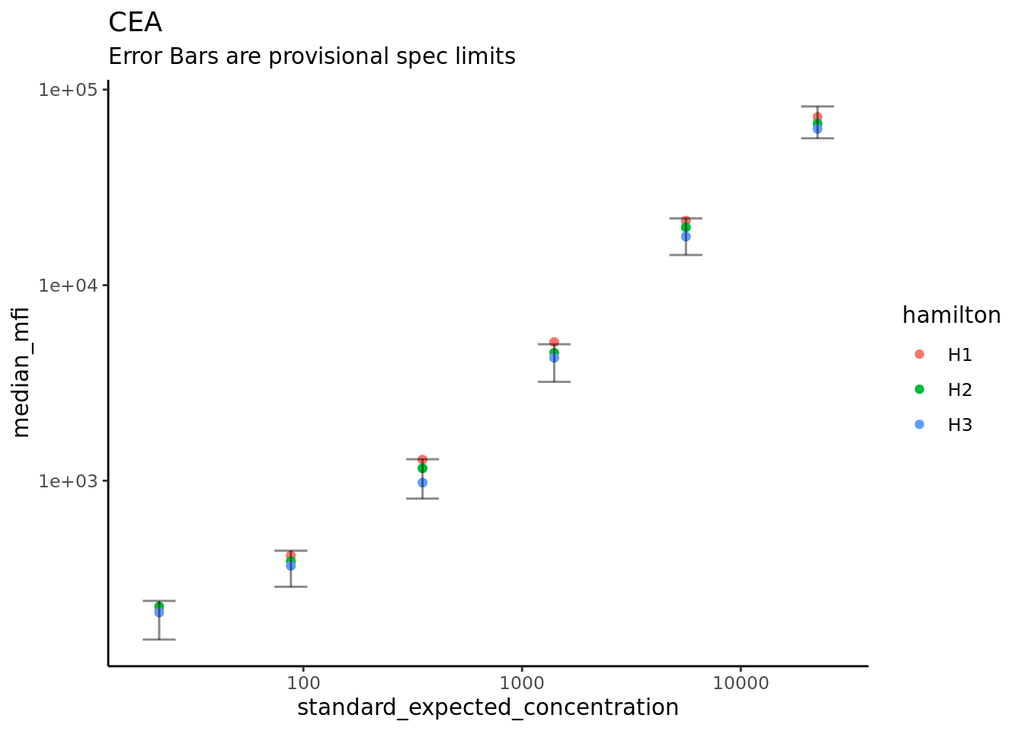

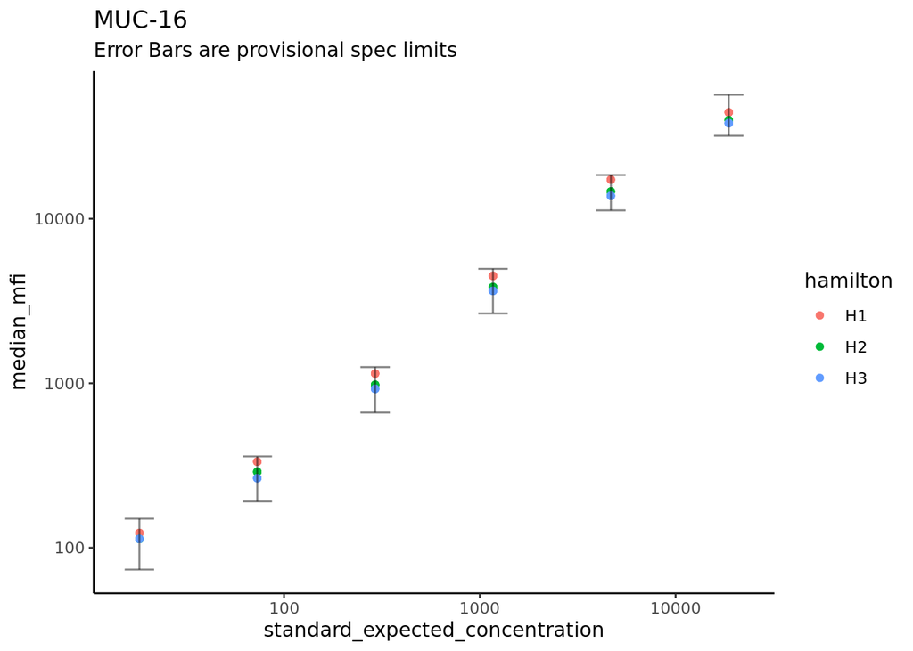

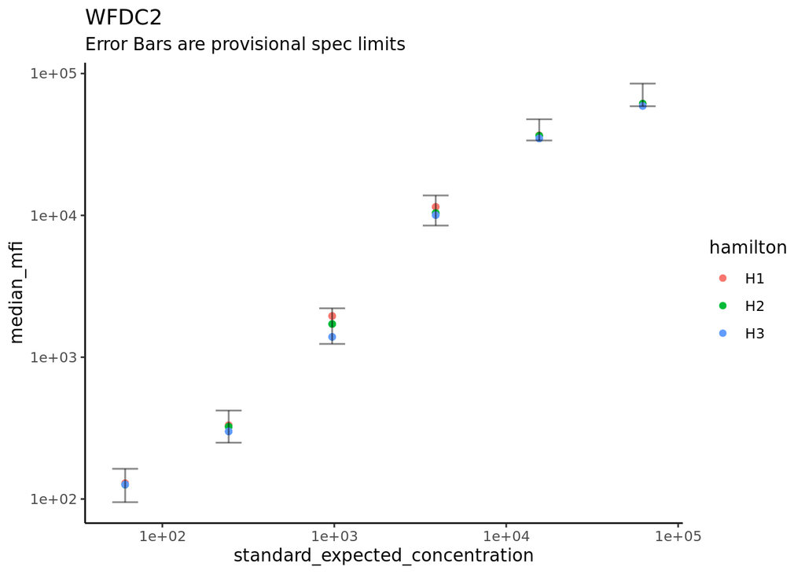

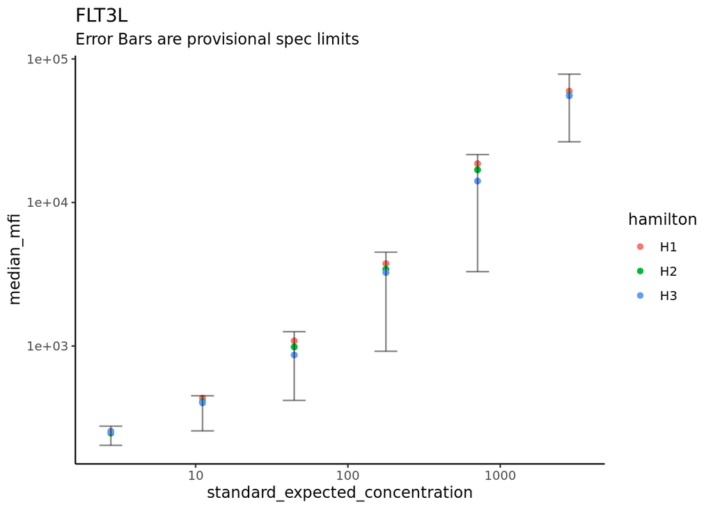

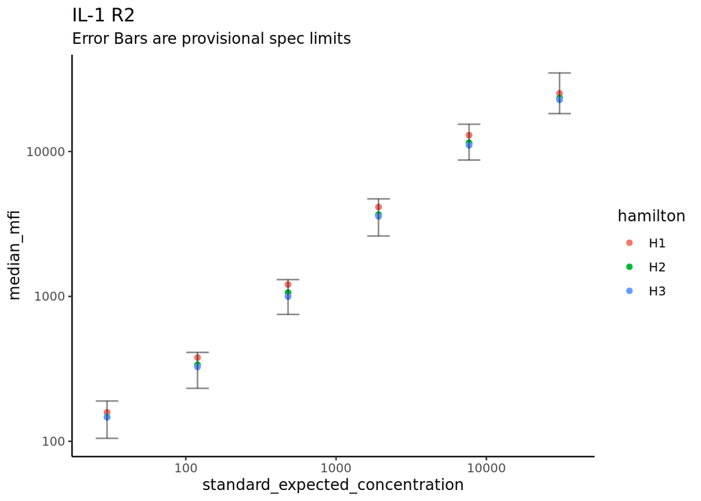

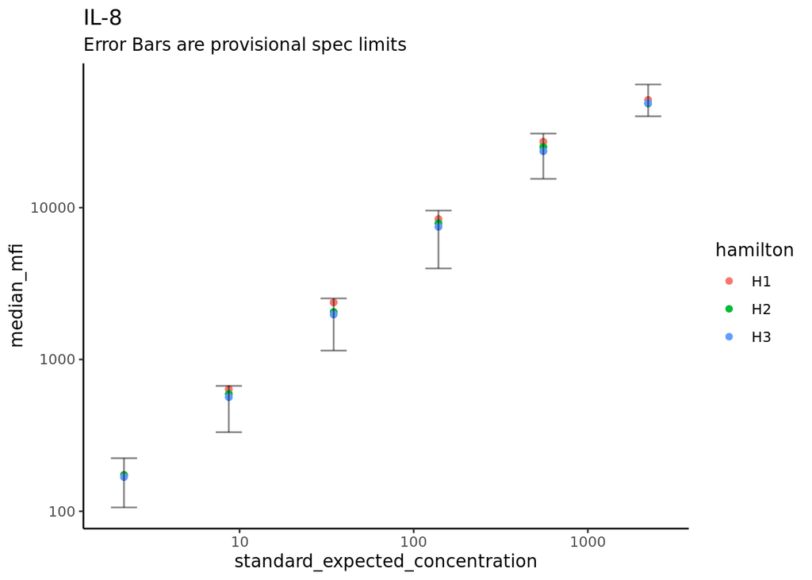

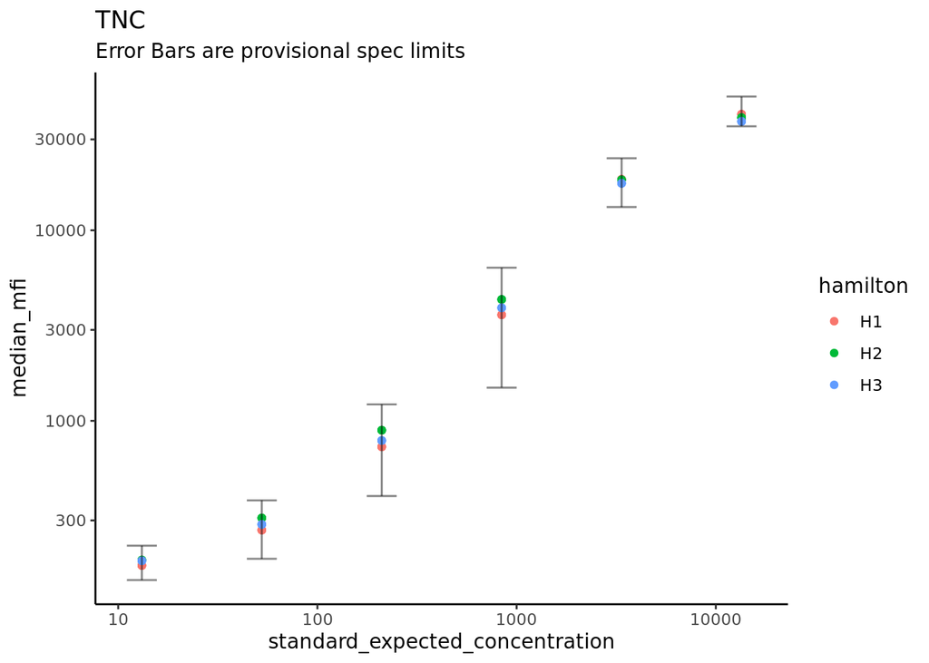

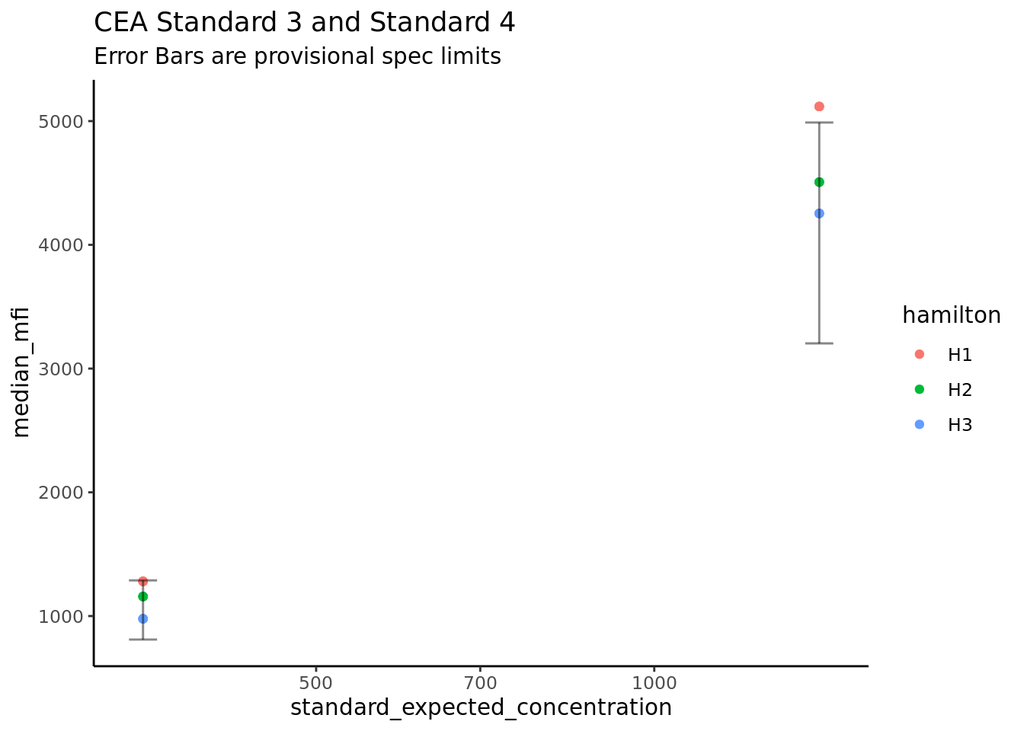